# Natural Language Dataset Exploration

Chris Hawkins

24 December 2015

## Overview

The objective of this report is to present findings in around 0.5 GB of natural language text data acquired from several data sources. The following data files were used:

| Name | Size |
| --- | --- |
| en_US.blogs.txt | 200M |
| en_US.news.txt | 196M |
| en_US.twitter.txt | 159M |

The eventual goal of this work is to use the natural language data set to predict the “next best word” given a source sentence. E.g. given: “a case of” the system will generate a suitable next word, such as “beer”.

## Exploratory Analysis

Before we begin the analysis, data must be downloaded and prepared.

1. the data is downloaded from a hosted location
2. the data is unzipped
3. the data is loaded into the R environment

The R code in listing 1 (see appendix) reproduces the steps taken to prepare and load the data.

To reduce unnecessary data (duplicate words with different punctuation and casing) and improve our results, the data is normalized to lowercase and all non-word characters are replaced with space. The code for this can be found in listing 2 (see appendix).

Some basic summary statistics give us the following table (note when making comparisons that these statistics are from after the removal of punctuation):

| name | num_rows | word_count | distinct_words | length_in_chars | longest_line_length | top_three_words | bottom_three_words |
| --- | --- | --- | --- | --- | --- | --- | --- |
| twitter | 2360148 | 31150952 | 326591 | 156452880 | 140 | the, i, to | janusas, bingonized, inrule |
| blogs | 899288 | 38378041 | 268888 | 202017730 | 40083 | the, and, to | bbcr4today, mells, raafi |
| news | 1010242 | 35793023 | 227631 | 198512925 | 11256 | the, to, a | frane, inshort, hilyer |

## Observations

While Twitter makes up the largest dataset in terms of number of samples, Blogs and News provide significantly longer samples. This is to be expected based on the respective natures of the mediums involved (Twitter is limited to 140 characters).

In all cases the the top three words are relatively familiar stop words from the English language. These words should be kept for this analysis as it is important to correctly predict stop word usage.

The bottom three words in all cases are not necessarily words we will ever want to predict. A recommendation going forward would be to remove words (or phrases/n-grams) that occur only once from the dataset.

## More Detailed Look at Word Frequencies

### Word Frequencies for Twitter

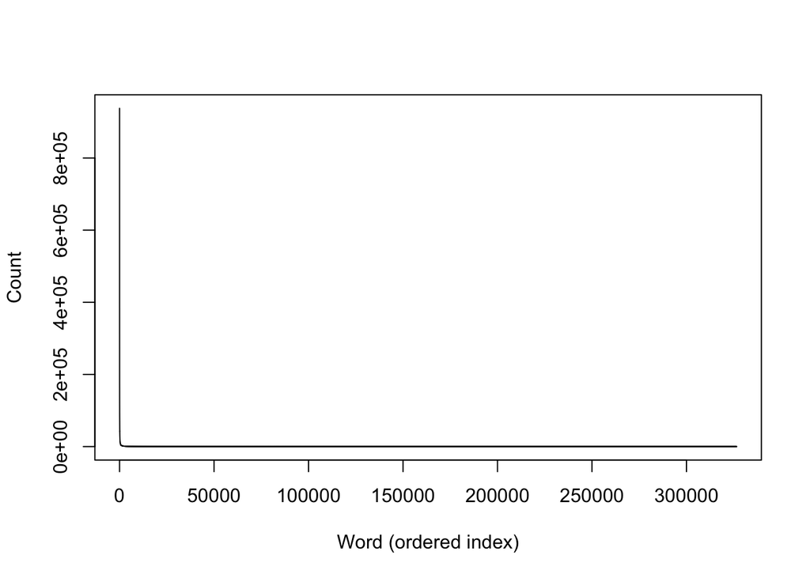

### Word Frequencies for Blogs

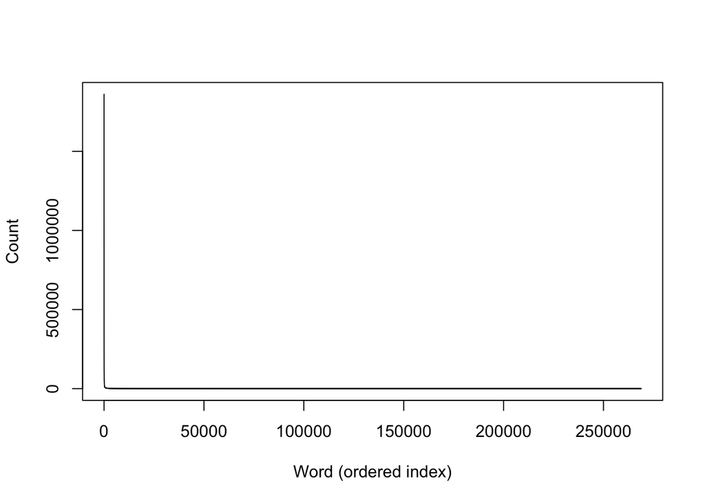

### Word Frequencies for News

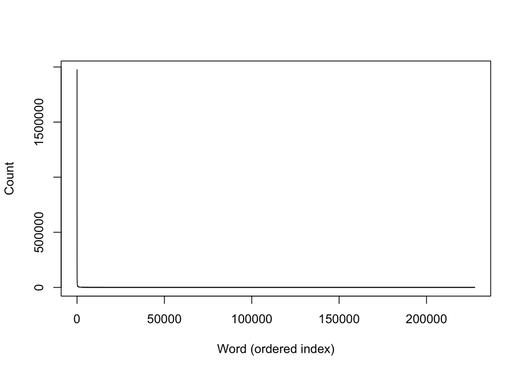

For example in the Twitter dataset the top twenty words make up a whopping 26.6% of the total word count:

|  | word | count | percent |
| --- | --- | --- | --- |
| 323673 | the | 937812 | 3.01% |
| 144696 | i | 918556 | 2.95% |
| 154620 | to | 788883 | 2.53% |
| 105793 | a | 615202 | 1.97% |
| 160429 | you | 601275 | 1.93% |
| 309934 | and | 438705 | 1.41% |
| 10052 | for | 385442 | 1.24% |
| 98989 | it | 383715 | 1.23% |
| 24044 | in | 380583 | 1.22% |
| 308339 | of | 359688 | 1.15% |
| 30708 | is | 358917 | 1.15% |
| 11944 | s | 312992 | 1.00% |
| 191984 | my | 292125 | 0.94% |
| 187656 | on | 278233 | 0.89% |
| 149134 | that | 271078 | 0.87% |
| 78110 | t | 221075 | 0.71% |
| 204244 | me | 203307 | 0.65% |
| 256551 | be | 187967 | 0.60% |
| 178993 | at | 186820 | 0.60% |
| 224073 | with | 173515 | 0.56% |

## Final Note

As part of this exercise, to overcome performance limitations of R, I experimented with rewriting the code in Scala and running on a small Spark cluster. You can see my adhoc Spark code (intended to be copied into Spark Shell) at my Github repository https://github.com/chrishawkins/datasci-capstone.

## Appendix

### Listing 1

```r
download.file("https://d396qusza40orc.cloudfront.net/dsscapstone/dataset/Coursera-SwiftKey.zip",
              "Coursera-SwiftKey.zip")
unzip("Coursera-SwiftKey.zip")

lang <- "en_US"
directory = paste("final/", lang, "/", sep = "")
rootfilename <- paste("final/", lang, "/", lang, sep = "")

# load tweets
twitter <- read.delim(paste(rootfilename, ".twitter.txt", sep = ""),
                      header = F, sep = "\t", colClasses = c(character()))

# load blogs
blogs <- read.delim(paste(rootfilename, ".blogs.txt", sep = ""),
                    header = F, sep = "\t", colClasses = c(character()))

# load news
news <- read.delim(paste(rootfilename, ".news.txt", sep = ""),
                   header = F, sep = "\t", colClasses = c(character()))
```

### Listing 2

```r
cleanse_normalize <- function(sentence) {
    return(tolower(gsub("\\W+", " ", sentence)))
}

cleansed_twitter <- cleanse_normalize(twitter)
cleansed_blogs <- cleanse_normalize(blogs)
cleansed_news <- cleanse_normalize(news)
```

### Listing 3

```r
word_count <- function(sentence) {
    no_spaces <- gsub(" ", "", sentence)
    return (nchar(sentence) - nchar(no_spaces))
}

word_freq <- function(sentence) {
    df <- as.data.frame(table(strsplit(sentence, " ")))
    colnames(df) <- c("word", "freq")
    return(df)
}

summary_stats <- function(name, text) {
    word_counts <- apply(text, 1, FUN=word_count)
    char_counts <- apply(text, 1, FUN=nchar)
    word_freqs <- apply(text, 1, FUN=word_freq)

    rows <- nrow(text)

    all_freqs <- do.call("rbind", word_freqs)
    total_freqs <- aggregate(all_freqs$freq, by=list(word=all_freqs$word), FUN=sum)

    top3 <- total_freqs[order(-total_freqs$x),][1:3, c("word")]
    bottom3 <- total_freqs[order(total_freqs$x),][1:3, c("word")]

    top3_str <- paste(top3, collapse=", ")
    bottom3_str <- paste(bottom3, collapse=", ")

    total_words = sum(word_counts)
    total_chars = sum(char_counts)
    longest_line_length = max(char_counts)
    distinct_words = nrow(total_freqs)

    return(data.frame(name = name,
                                num_rows = rows,
                              word_count = total_words,
                              distinct_words = distinct_words,
                              length_in_chars = total_chars,
                              longest_line_length = longest_line_length,
                              top_three_words = top3_str,
                              bottom_three_words = bottom3_str))
}

twitter_stats <- summary_stats("twitter", cleansed_twitter)
blogs_stats <- summary_stats("blogs", cleansed_blogs)
news_stats <- summary_stats("news", cleansed_news)

all_stats = rbind(twitter_stats, blogs_stats, news_stats)
```

### Listing 4

```r
freq_plot <- function(name, text) {
    word_freqs <- apply(text, 1, FUN=word_freq)
    all_freqs <- do.call("rbind", word_freqs)
    total_freqs <- aggregate(all_freqs$freq, by=list(word=all_freqs$word), FUN=sum)

    plot(total_freqs$x, type="l", xlab="Word (ordered index)", ylab="Count")
}

freq_plot(cleansed_twitter)
freq_plot(cleansed_blogs)
freq_plot(cleansed_news)
```